# Predict Workout Style

Jayesh Gokhale

5/8/2021

# Predict Workout Style

## Executive Summary

On basis of measurement of body movements, we have to detect whether an exercise was performed in correct fashion or one of the incorrect fashions. All of them have been categorized in classes A, B, C, D and E in the classe variable.

## Approach

1. Explore Data Set
2. Clean Data Set
3. Identify which variables may be significant (remove multi collinearity)
4. Build Models
5. Do Cross Validation
6. Make Prediction on Test Set

Let us download the files first

```r
if (!file.exists("pml-training.csv"))
{
  download.file(url="https://d396qusza40orc.cloudfront.net/predmachlearn/pml-training.csv",
                destfile = "pml-training.csv",method="curl")
}

if (!file.exists("pml-testing.csv"))
{
  download.file(url="https://d396qusza40orc.cloudfront.net/predmachlearn/pml-testing.csv",
                destfile = "pml-testing.csv",method="curl")
}
```

Let us now load libraries

```r
library(ggplot2)
library(RColorBrewer)
library(knitr)
library(kableExtra)
library(reshape2)
library(ggpubr)
library(caret)
```

Let us load the data

```r
df.train <- read.csv("pml-training.csv")
df.test <- read.csv("pml-testing.csv")
```

## Data Exploration

1. There are many variables which have far too many NA values
2. There are some numeric factor variables which have a level named #DIV/0 and these have disproportionate number of such values. We will convert them to NA.
3. There are some numeric factor values which have level named as blank and these too have disproportionate number of such values. We will convert them to NA.

So my strategy would be to find the variables where NA values are greater than 95% (this is just a gut feel number and no science as such behind it).

```r
areAllNA <- function(myvector,epsilon=1)
{
  if ((sum(is.na(myvector))/length(myvector)) >= epsilon) return(TRUE)
  return(FALSE)
}

getNAProportion <- function(myvector)
{
  na.proportion <- sum(is.na(myvector))/as.numeric(length(myvector))
  return(na.proportion)
}
# These below values are treated as NA
df.train[df.train=="#DIV/0!"] <- NA
df.train[df.train==""] <- NA

allNACols <- apply(df.train,2,areAllNA,epsilon=0.95)
legit.Cols <- names(allNACols[allNACols==FALSE])

legit.Cols
```

```
##  [1] "X"                    "user_name"            "raw_timestamp_part_1"
##  [4] "raw_timestamp_part_2" "cvtd_timestamp"       "new_window"
##  [7] "num_window"           "roll_belt"            "pitch_belt"
## [10] "yaw_belt"             "total_accel_belt"     "gyros_belt_x"
## [13] "gyros_belt_y"         "gyros_belt_z"         "accel_belt_x"
## [16] "accel_belt_y"         "accel_belt_z"         "magnet_belt_x"
## [19] "magnet_belt_y"        "magnet_belt_z"        "roll_arm"
## [22] "pitch_arm"            "yaw_arm"              "total_accel_arm"
## [25] "gyros_arm_x"          "gyros_arm_y"          "gyros_arm_z"
## [28] "accel_arm_x"          "accel_arm_y"          "accel_arm_z"
## [31] "magnet_arm_x"         "magnet_arm_y"         "magnet_arm_z"
## [34] "roll_dumbbell"        "pitch_dumbbell"       "yaw_dumbbell"
## [37] "total_accel_dumbbell" "gyros_dumbbell_x"     "gyros_dumbbell_y"
## [40] "gyros_dumbbell_z"     "accel_dumbbell_x"     "accel_dumbbell_y"
## [43] "accel_dumbbell_z"     "magnet_dumbbell_x"    "magnet_dumbbell_y"
## [46] "magnet_dumbbell_z"    "roll_forearm"         "pitch_forearm"
## [49] "yaw_forearm"          "total_accel_forearm"  "gyros_forearm_x"
## [52] "gyros_forearm_y"      "gyros_forearm_z"      "accel_forearm_x"
## [55] "accel_forearm_y"      "accel_forearm_z"      "magnet_forearm_x"
## [58] "magnet_forearm_y"     "magnet_forearm_z"     "classe"
```

```r
df.train <- df.train[legit.Cols]
```

Let us explore the data

```r
summary(df.train)
```

```
##        X            user_name    raw_timestamp_part_1 raw_timestamp_part_2
##  Min.   :    1   adelmo  :3892   Min.   :1.322e+09    Min.   :   294
##  1st Qu.: 4906   carlitos:3112   1st Qu.:1.323e+09    1st Qu.:252912
##  Median : 9812   charles :3536   Median :1.323e+09    Median :496380
##  Mean   : 9812   eurico  :3070   Mean   :1.323e+09    Mean   :500656
##  3rd Qu.:14717   jeremy  :3402   3rd Qu.:1.323e+09    3rd Qu.:751891
##  Max.   :19622   pedro   :2610   Max.   :1.323e+09    Max.   :998801
##
##           cvtd_timestamp  new_window    num_window      roll_belt
##  28/11/2011 14:14: 1498   no :19216   Min.   :  1.0   Min.   :-28.90
##  05/12/2011 11:24: 1497   yes:  406   1st Qu.:222.0   1st Qu.:  1.10
##  30/11/2011 17:11: 1440               Median :424.0   Median :113.00
##  05/12/2011 11:25: 1425               Mean   :430.6   Mean   : 64.41
##  02/12/2011 14:57: 1380               3rd Qu.:644.0   3rd Qu.:123.00
##  02/12/2011 13:34: 1375               Max.   :864.0   Max.   :162.00
##  (Other)         :11007
##    pitch_belt          yaw_belt       total_accel_belt  gyros_belt_x
##  Min.   :-55.8000   Min.   :-180.00   Min.   : 0.00    Min.   :-1.040000
##  1st Qu.:  1.7600   1st Qu.: -88.30   1st Qu.: 3.00    1st Qu.:-0.030000
##  Median :  5.2800   Median : -13.00   Median :17.00    Median : 0.030000
##  Mean   :  0.3053   Mean   : -11.21   Mean   :11.31    Mean   :-0.005592
##  3rd Qu.: 14.9000   3rd Qu.:  12.90   3rd Qu.:18.00    3rd Qu.: 0.110000
##  Max.   : 60.3000   Max.   : 179.00   Max.   :29.00    Max.   : 2.220000
##
##   gyros_belt_y       gyros_belt_z      accel_belt_x       accel_belt_y
##  Min.   :-0.64000   Min.   :-1.4600   Min.   :-120.000   Min.   :-69.00
##  1st Qu.: 0.00000   1st Qu.:-0.2000   1st Qu.: -21.000   1st Qu.:  3.00
##  Median : 0.02000   Median :-0.1000   Median : -15.000   Median : 35.00
##  Mean   : 0.03959   Mean   :-0.1305   Mean   :  -5.595   Mean   : 30.15
##  3rd Qu.: 0.11000   3rd Qu.:-0.0200   3rd Qu.:  -5.000   3rd Qu.: 61.00
##  Max.   : 0.64000   Max.   : 1.6200   Max.   :  85.000   Max.   :164.00
##
##   accel_belt_z     magnet_belt_x   magnet_belt_y   magnet_belt_z
##  Min.   :-275.00   Min.   :-52.0   Min.   :354.0   Min.   :-623.0
##  1st Qu.:-162.00   1st Qu.:  9.0   1st Qu.:581.0   1st Qu.:-375.0
##  Median :-152.00   Median : 35.0   Median :601.0   Median :-320.0
##  Mean   : -72.59   Mean   : 55.6   Mean   :593.7   Mean   :-345.5
##  3rd Qu.:  27.00   3rd Qu.: 59.0   3rd Qu.:610.0   3rd Qu.:-306.0
##  Max.   : 105.00   Max.   :485.0   Max.   :673.0   Max.   : 293.0
##
```

[output cut: 65 more lines]

```
##  Min.   : -8.0900   Min.   :-498.00   Min.   :-632.0   Min.   :-446.00
##  1st Qu.: -0.1800   1st Qu.:-178.00   1st Qu.:  57.0   1st Qu.:-182.00
##  Median :  0.0800   Median : -57.00   Median : 201.0   Median : -39.00
##  Mean   :  0.1512   Mean   : -61.65   Mean   : 163.7   Mean   : -55.29
##  3rd Qu.:  0.4900   3rd Qu.:  76.00   3rd Qu.: 312.0   3rd Qu.:  26.00
##  Max.   :231.0000   Max.   : 477.00   Max.   : 923.0   Max.   : 291.00
##
##  magnet_forearm_x  magnet_forearm_y magnet_forearm_z classe
##  Min.   :-1280.0   Min.   :-896.0   Min.   :-973.0   A:5580
##  1st Qu.: -616.0   1st Qu.:   2.0   1st Qu.: 191.0   B:3797
##  Median : -378.0   Median : 591.0   Median : 511.0   C:3422
##  Mean   : -312.6   Mean   : 380.1   Mean   : 393.6   D:3216
##  3rd Qu.:  -73.0   3rd Qu.: 737.0   3rd Qu.: 653.0   E:3607
##  Max.   :  672.0   Max.   :1480.0   Max.   :1090.0
##
```

```r
str(df.train)
```

```
## 'data.frame':    19622 obs. of  60 variables:
##  $ X                   : int  1 2 3 4 5 6 7 8 9 10 ...
##  $ user_name           : Factor w/ 6 levels "adelmo","carlitos",..: 2 2 2 2 2 2 2 2 2 2 ...
##  $ raw_timestamp_part_1: int  1323084231 1323084231 1323084231 1323084232 1323084232 1323084232 1323084232 1323084232 1323084232 1323084232 ...
##  $ raw_timestamp_part_2: int  788290 808298 820366 120339 196328 304277 368296 440390 484323 484434 ...
##  $ cvtd_timestamp      : Factor w/ 20 levels "02/12/2011 13:32",..: 9 9 9 9 9 9 9 9 9 9 ...
##  $ new_window          : Factor w/ 2 levels "no","yes": 1 1 1 1 1 1 1 1 1 1 ...
##  $ num_window          : int  11 11 11 12 12 12 12 12 12 12 ...
##  $ roll_belt           : num  1.41 1.41 1.42 1.48 1.48 1.45 1.42 1.42 1.43 1.45 ...
##  $ pitch_belt          : num  8.07 8.07 8.07 8.05 8.07 8.06 8.09 8.13 8.16 8.17 ...
##  $ yaw_belt            : num  -94.4 -94.4 -94.4 -94.4 -94.4 -94.4 -94.4 -94.4 -94.4 -94.4 ...
##  $ total_accel_belt    : int  3 3 3 3 3 3 3 3 3 3 ...
##  $ gyros_belt_x        : num  0 0.02 0 0.02 0.02 0.02 0.02 0.02 0.02 0.03 ...
##  $ gyros_belt_y        : num  0 0 0 0 0.02 0 0 0 0 0 ...
##  $ gyros_belt_z        : num  -0.02 -0.02 -0.02 -0.03 -0.02 -0.02 -0.02 -0.02 -0.02 0 ...
```

[output cut: 46 more lines]

## Feature Analysis

Now the thing is that there are far too many variables observing each and every one of them manually would be extremely time consuming. Let us do one thing: Let us do a **one way ANOVA** to get F-Statistic and order these by decrease order of F-Statistic and pick only some top N variables.

```r
getSignificanceValue <- function(dfvar,classe)
{
  if(is.factor(dfvar)) return(-1)
  res.aov <- aov(dfvar ~ classe)
  f.statistic <- summary(res.aov)[[1]][1,4]
  return(f.statistic)
}

signif.vars <- lapply(df.train,getSignificanceValue,classe=df.train$classe)
signif.vars <- do.call("rbind",signif.vars)
signif.vars <- as.data.frame(signif.vars)
signif.vars$column_name <- rownames(signif.vars)
colnames(signif.vars) <- c("AOV_F_STATISTIC","COLUMN_NAME")
signif.vars <- signif.vars[c("COLUMN_NAME","AOV_F_STATISTIC")]
signif.vars <- signif.vars[order(-signif.vars$AOV_F_STATISTIC),]
```

### F Statistics

Based on the table below we will try our luck with the variables which have three digit F Statistics (ignore the variable:X obviously)

```r
signif.vars
```

```
##                               COLUMN_NAME AOV_F_STATISTIC
## X                                       X    1.013371e+05
## pitch_forearm               pitch_forearm    1.120391e+03
## magnet_belt_y               magnet_belt_y    6.794003e+02
## magnet_arm_x                 magnet_arm_x    6.597862e+02
## magnet_arm_y                 magnet_arm_y    4.853915e+02
## accel_arm_x                   accel_arm_x    4.618721e+02
## roll_dumbbell               roll_dumbbell    4.230659e+02
## accel_forearm_x           accel_forearm_x    4.127945e+02
## pitch_dumbbell             pitch_dumbbell    4.123544e+02
## accel_dumbbell_x         accel_dumbbell_x    3.936704e+02
## magnet_arm_z                 magnet_arm_z    3.718036e+02
## magnet_forearm_x         magnet_forearm_x    3.202271e+02
## magnet_belt_z               magnet_belt_z    3.016916e+02
## num_window                     num_window    2.234171e+02
## pitch_arm                       pitch_arm    2.041460e+02
## magnet_forearm_y         magnet_forearm_y    1.875448e+02
## total_accel_forearm   total_accel_forearm    1.497815e+02
## roll_arm                         roll_arm    1.420621e+02
## magnet_dumbbell_z       magnet_dumbbell_z    1.413877e+02
## magnet_dumbbell_x       magnet_dumbbell_x    1.221925e+02
## accel_dumbbell_z         accel_dumbbell_z    1.107476e+02
## accel_dumbbell_y         accel_dumbbell_y    1.084454e+02
## total_accel_arm           total_accel_arm    1.061225e+02
## roll_forearm                 roll_forearm    8.279001e+01
## accel_forearm_y           accel_forearm_y    7.961851e+01
## accel_arm_z                   accel_arm_z    7.402061e+01
## total_accel_dumbbell total_accel_dumbbell    6.895138e+01
## yaw_dumbbell                 yaw_dumbbell    6.568602e+01
## yaw_forearm                   yaw_forearm    6.021097e+01
## accel_arm_y                   accel_arm_y    5.778271e+01
## yaw_arm                           yaw_arm    5.715743e+01
## magnet_dumbbell_y       magnet_dumbbell_y    5.316731e+01
## magnet_forearm_z         magnet_forearm_z    4.971418e+01
## accel_belt_z                 accel_belt_z    4.642630e+01
## total_accel_belt         total_accel_belt    3.834788e+01
## magnet_belt_x               magnet_belt_x    3.493044e+01
## roll_belt                       roll_belt    3.407606e+01
## gyros_dumbbell_y         gyros_dumbbell_y    1.815987e+01
## accel_belt_x                 accel_belt_x    1.176321e+01
## raw_timestamp_part_1 raw_timestamp_part_1    1.158933e+01
## gyros_forearm_x           gyros_forearm_x    9.396928e+00
## accel_forearm_z           accel_forearm_z    9.228644e+00
## yaw_belt                         yaw_belt    9.223165e+00
## accel_belt_y                 accel_belt_y    9.113853e+00
## gyros_belt_x                 gyros_belt_x    8.153477e+00
## pitch_belt                     pitch_belt    7.100528e+00
## gyros_arm_y                   gyros_arm_y    4.304029e+00
## gyros_belt_y                 gyros_belt_y    3.251128e+00
## gyros_belt_z                 gyros_belt_z    3.112336e+00
## gyros_dumbbell_x         gyros_dumbbell_x    1.899251e+00
## raw_timestamp_part_2 raw_timestamp_part_2    1.860478e+00
## gyros_arm_x                   gyros_arm_x    9.376223e-01
## gyros_forearm_y           gyros_forearm_y    8.428099e-01
## gyros_forearm_z           gyros_forearm_z    6.763135e-01
## gyros_arm_z                   gyros_arm_z    6.212214e-01
## gyros_dumbbell_z         gyros_dumbbell_z    4.598443e-01
## user_name                       user_name   -1.000000e+00
## cvtd_timestamp             cvtd_timestamp   -1.000000e+00
## new_window                     new_window   -1.000000e+00
## classe                             classe   -1.000000e+00
```

## Heat Maps

Amongst all the variables for whom F Statistic is three digit (>= 100), there might be some which have multi-collinearity amongst them. We would want to exclude them to avoid variance issues. Let us draw a heat map of Pearson correlation.

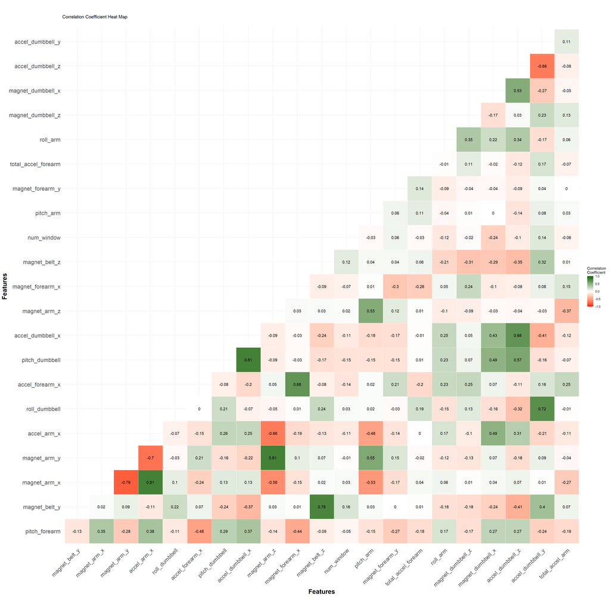

```r
f.stat.100 <- signif.vars[signif.vars$AOV_F_STATISTIC >= 100,]$COLUMN_NAME
f.stat.100 <- f.stat.100[!(f.stat.100 %in% "X")]

correlation.matrix <- cor(df.train[f.stat.100])
correlation.matrix <- round(correlation.matrix,2)
correlation.matrix[upper.tri(correlation.matrix)] <- NA
diag(correlation.matrix) <- NA
row.corr.matrix <- melt(correlation.matrix,na.rm=TRUE)
colnames(row.corr.matrix) <- c("F1","F2","CORR")

heatMap <- ggplot(data = row.corr.matrix, aes(x=F1, y=F2, fill=CORR)) +
  geom_tile(color="white")+
  labs(title = "Correlation Coefficient Heat Map",
       subtitle = "",
       y = "Features", x = "Features") +
  scale_fill_gradient2(low = "red", high = "darkgreen", mid = "white",
   midpoint = 0, limit = c(-1,1), space = "Lab",
   name="Correlation\nCoefficient") +
  theme_minimal()+
 theme(axis.text.x = element_text(angle = 45, vjust = 1,
    size = 16, hjust = 1), axis.text.y = element_text(size = 16))+
 coord_fixed()+
  geom_text(aes(x=F1, y=F2, label = CORR), color = "black", size = 4) +
    theme(axis.title=element_text(size=18,face="bold"))

heatMap
```

### Heatmap Observations

It is difficult to observe the heatmap from the HTML file. I have manually saved the heatmap as a PNG file and magnified it to make my observations. So the extreme correlation cases (on either side of 0.8 and -0.8 approx) should be excluded from the model.

From the Heat Map we get some exclusions as under -

**exclude**: magnet_belt_z (due to inclusion of magnet_belt_y)

**exclude**: magnet_arm_y (due to inclusion of magnet_arm_x)

**exclude**: accel_arm_x (due to inclusion of magnet_arm_x)

**exclude**: accel_dumbbell_x (due to inclusion of pitch_dumbbell)

**exclude**: accel_dumbbell_y (due to inclusion of roll_dumbbell)

```r
removals <- c('magnet_belt_z',
'magnet_arm_y',
'accel_arm_x',
'accel_dumbbell_x',
'accel_dumbbell_y'
)

f.stat.100 <- f.stat.100[!(f.stat.100 %in% removals)]
f.stat.100
```

```
##  [1] "pitch_forearm"       "magnet_belt_y"       "magnet_arm_x"
##  [4] "roll_dumbbell"       "accel_forearm_x"     "pitch_dumbbell"
##  [7] "magnet_arm_z"        "magnet_forearm_x"    "num_window"
## [10] "pitch_arm"           "magnet_forearm_y"    "total_accel_forearm"
## [13] "roll_arm"            "magnet_dumbbell_z"   "magnet_dumbbell_x"
## [16] "accel_dumbbell_z"    "total_accel_arm"
```

```r
length(f.stat.100)
```

```
## [1] 17
```

## Box Plot

Let us draw box plots of all the chosen variables

```r
getBoxPlot <- function(df,xvar,yvar,fillvar,xlabel,ylabel,filllabel)
{
  mybox <- ggplot(data=df, aes(x=xvar,y=yvar,fill=xvar)) +
  geom_boxplot(outlier.colour="black",
               outlier.size=1,position=position_dodge(1)) +
  labs(title = "",
       subtitle = "",
       y = ylabel, x = xlabel) +
    scale_fill_brewer(name = filllabel,palette="YlGnBu")  + #Dark2
    theme(legend.position = "none") +
    theme(axis.text=element_text(size=14),
        axis.title=element_text(size=18,face="bold")) +
  theme(plot.title = element_text(hjust = 0.5))

  return(mybox)
}

signif.vars.short <- signif.vars[2:7,]


mytextmain <- "figure.box <- ggarrange("

for (i in 1:length(f.stat.100))
{
  mytext <- paste0("plot",i," <-  getBoxPlot(df.train,df.train$classe,df.train$",f.stat.100[i],
                   ",'','Class','",f.stat.100[i],"','')")
  mytextmain <- paste0(mytextmain,"plot",i,",")
  eval(parse(text=mytext))
}

mytextmain <- paste0(mytextmain," ncol = 4, nrow = ",ceiling(length(f.stat.100)/4), ")")
eval(parse(text=mytextmain))
```

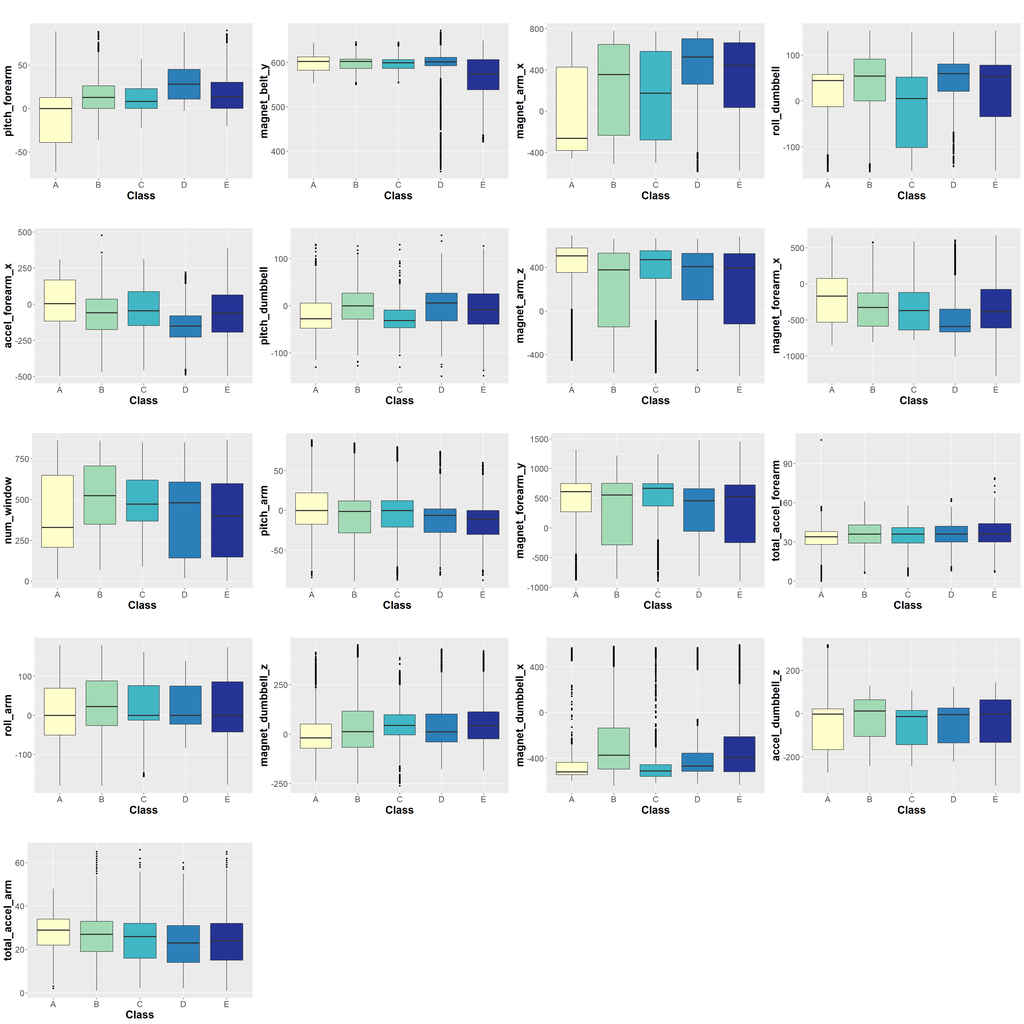

```r
figure.box
```

### Box Plot Observations

We can see that there is some amount of variance amongst classes in each of these variables as indicated by the one way ANOVA test. Let us try building a model using all of these.

## Model Building

Let us first try to build a basic Multi-Nomial Regression and see where we stand

## Multinomial Regression

```r
predictor.vars <- f.stat.100
set.seed(1234)
trainIndex = createDataPartition(df.train$classe, p = 0.8,list=FALSE)
training = df.train[trainIndex,]
testing = df.train[-trainIndex,]

mytext <- "modMultiNom <- train(classe~"
mytext <- paste0(mytext,paste(predictor.vars,collapse="+"))
mytext <- paste0(mytext,",data=training,method='multinom',trace=FALSE)")
eval(parse(text=mytext))
```

```r
prediction.train.multinom <- predict(modMultiNom)
prediction.CV.multinom <- predict(modMultiNom,testing)
```

## Confusion Matrix for Cross Validation (Multi Nomial Model)

```r
confusionMatrix(prediction.CV.multinom,testing$classe)
```

```
## Confusion Matrix and Statistics
##
##           Reference
## Prediction   A   B   C   D   E
##          A 784 172 158  50  94
##          B  83 338  75  61 114
##          C  86  91 348  89  81
##          D 100  96  57 371 103
##          E  63  62  46  72 329
##
## Overall Statistics
##
##                Accuracy : 0.5531
##                  95% CI : (0.5374, 0.5688)
##     No Information Rate : 0.2845
##     P-Value [Acc > NIR] : < 2.2e-16
##
##                   Kappa : 0.4327
##
##  Mcnemar's Test P-Value : < 2.2e-16
##
## Statistics by Class:
##
##                      Class: A Class: B Class: C Class: D Class: E
## Sensitivity            0.7025  0.44532  0.50877  0.57698  0.45631
## Specificity            0.8311  0.89475  0.89287  0.89146  0.92411
## Pos Pred Value         0.6232  0.50373  0.50072  0.51032  0.57517
## Neg Pred Value         0.8754  0.87054  0.89591  0.91489  0.88302
## Prevalence             0.2845  0.19347  0.17436  0.16391  0.18379
## Detection Rate         0.1998  0.08616  0.08871  0.09457  0.08386
## Detection Prevalence   0.3207  0.17104  0.17716  0.18532  0.14581
## Balanced Accuracy      0.7668  0.67004  0.70082  0.73422  0.69021
```

### Multinomial Regression Observations

Our Cross Validation Accuracy is just over 50% which is not great. Perhaps the reason for that is that partition boundary on the hyper-plane is not linear. Let us try non-linear approaches like Decision Trees.

## Decision Tree

```r
set.seed(1234)
mytext <- "modDT <- train(classe~"
mytext <- paste0(mytext,paste(predictor.vars,collapse="+"))
mytext <- paste0(mytext,",data=training,method='rpart')")
eval(parse(text=mytext))
```

```r
prediction.train.DT <- predict(modDT)
prediction.CV.DT <- predict(modDT,testing)
```

## Confusion Matrix for Cross Validation (Decision Tree Model)

```r
confusionMatrix(prediction.CV.DT,testing$classe)
```

```
## Confusion Matrix and Statistics
##
##           Reference
## Prediction   A   B   C   D   E
##          A 953 145  72 160 192
##          B  73 399  60 138 150
##          C  90 215 552 296 147
##          D   0   0   0   0   0
##          E   0   0   0  49 232
##
## Overall Statistics
##
##                Accuracy : 0.5445
##                  95% CI : (0.5287, 0.5602)
##     No Information Rate : 0.2845
##     P-Value [Acc > NIR] : < 2.2e-16
##
##                   Kappa : 0.4147
##
##  Mcnemar's Test P-Value : < 2.2e-16
##
## Statistics by Class:
##
##                      Class: A Class: B Class: C Class: D Class: E
## Sensitivity            0.8539   0.5257   0.8070   0.0000  0.32178
## Specificity            0.7973   0.8669   0.7691   1.0000  0.98470
## Pos Pred Value         0.6261   0.4866   0.4246      NaN  0.82562
## Neg Pred Value         0.9321   0.8840   0.9497   0.8361  0.86573
## Prevalence             0.2845   0.1935   0.1744   0.1639  0.18379
## Detection Rate         0.2429   0.1017   0.1407   0.0000  0.05914
## Detection Prevalence   0.3880   0.2090   0.3314   0.0000  0.07163
## Balanced Accuracy      0.8256   0.6963   0.7880   0.5000  0.65324
```

### Decision Tree Observations

Our Cross Validation Accuracy is no better than Multi Nomial. Let us try for a Random Forest Classifier with K-Fold Cross Validation.

## Random Forest Classification with K-Fold Cross Validation (K = 5)

```r
predictor.vars <- f.stat.100
set.seed(1234)
train_control<- trainControl(method="cv", number=5, savePredictions = TRUE)
mytext <- "myModel <- train(classe~"
mytext <- paste0(mytext,paste(predictor.vars,collapse="+"))
mytext <- paste0(mytext,",data=df.train,trControl=train_control,method='rf',trace=FALSE)")
eval(parse(text=mytext))
```

## Confusion Matrix on Cross Validation Data (Random Forest with 5-fold)

```r
model.kfold.predictions <- myModel$pred
list.predictions <- split(model.kfold.predictions,model.kfold.predictions$Resample)
cv.confusion.matrix <- lapply(list.predictions,function(df) confusionMatrix(df$pred,df$obs))
cv.confusion.matrix
```

```
## $Fold1
## Confusion Matrix and Statistics
##
##           Reference
## Prediction    A    B    C    D    E
##          A 3348    3    0    0    3
##          B    0 2267    6    0    2
##          C    0    8 2043   11    4
##          D    0    1    3 1918    7
##          E    0    1    0    0 2147
##
## Overall Statistics
##
##                Accuracy : 0.9958
##                  95% CI : (0.9945, 0.9969)
##     No Information Rate : 0.2844
##     P-Value [Acc > NIR] : < 2.2e-16
##
##                   Kappa : 0.9947
##
##  Mcnemar's Test P-Value : NA
##
## Statistics by Class:
##
##                      Class: A Class: B Class: C Class: D Class: E
## Sensitivity            1.0000   0.9943   0.9956   0.9943   0.9926
## Specificity            0.9993   0.9992   0.9976   0.9989   0.9999
## Pos Pred Value         0.9982   0.9965   0.9889   0.9943   0.9995
## Neg Pred Value         1.0000   0.9986   0.9991   0.9989   0.9983
## Prevalence             0.2844   0.1937   0.1743   0.1639   0.1837
## Detection Rate         0.2844   0.1926   0.1735   0.1629   0.1824
## Detection Prevalence   0.2849   0.1933   0.1755   0.1639   0.1825
## Balanced Accuracy      0.9996   0.9967   0.9966   0.9966   0.9962
##
## $Fold2
## Confusion Matrix and Statistics
##
##           Reference
## Prediction    A    B    C    D    E
##          A 3348    7    0    0    0
```

[output cut: 114 more lines]

```
##                   Kappa : 0.9934
##
##  Mcnemar's Test P-Value : NA
##
## Statistics by Class:
##
##                      Class: A Class: B Class: C Class: D Class: E
## Sensitivity            0.9988   0.9903   0.9976   0.9907   0.9945
## Specificity            0.9988   0.9989   0.9974   0.9987   0.9997
## Pos Pred Value         0.9970   0.9956   0.9880   0.9932   0.9986
## Neg Pred Value         0.9995   0.9977   0.9995   0.9982   0.9988
## Prevalence             0.2843   0.1934   0.1745   0.1638   0.1839
## Detection Rate         0.2840   0.1915   0.1741   0.1623   0.1829
## Detection Prevalence   0.2848   0.1924   0.1762   0.1634   0.1832
## Balanced Accuracy      0.9988   0.9946   0.9975   0.9947   0.9971
```

### Cross Validation Observations (Random Forest with 5-fold)

We can see that on every fold we have an accuracy of over 99% with over 99% Sensitivity and Specificity for each class. I think this model is good enough to deploy on test set :)

## Test Set Exploration

```r
summary(df.test[c(predictor.vars)])
```

```
##  pitch_forearm     magnet_belt_y    magnet_arm_x     roll_dumbbell
##  Min.   :-63.500   Min.   :566.0   Min.   :-428.00   Min.   :-111.118
##  1st Qu.:-11.457   1st Qu.:578.5   1st Qu.:-373.75   1st Qu.:   7.494
##  Median :  8.830   Median :600.5   Median :-265.00   Median :  50.403
##  Mean   :  7.099   Mean   :601.5   Mean   : -38.95   Mean   :  33.760
##  3rd Qu.: 28.500   3rd Qu.:631.2   3rd Qu.: 250.50   3rd Qu.:  58.129
##  Max.   : 59.300   Max.   :638.0   Max.   : 750.00   Max.   : 123.984
##  accel_forearm_x  pitch_dumbbell    magnet_arm_z    magnet_forearm_x
##  Min.   :-212.0   Min.   :-54.97   Min.   :-499.0   Min.   :-714.0
##  1st Qu.:-114.8   1st Qu.:-51.89   1st Qu.: 403.0   1st Qu.:-427.2
##  Median :  86.0   Median :-40.81   Median : 476.5   Median :-189.5
##  Mean   :  38.8   Mean   :-19.47   Mean   : 369.8   Mean   :-159.2
##  3rd Qu.: 166.2   3rd Qu.: 16.12   3rd Qu.: 517.0   3rd Qu.:  41.5
##  Max.   : 232.0   Max.   : 96.87   Max.   : 633.0   Max.   : 532.0
##    num_window      pitch_arm       magnet_forearm_y total_accel_forearm
##  Min.   : 48.0   Min.   :-63.800   Min.   :-787.0   Min.   :21.00
##  1st Qu.:250.0   1st Qu.: -9.188   1st Qu.:-328.8   1st Qu.:24.00
##  Median :384.5   Median :  0.000   Median : 487.0   Median :32.50
##  Mean   :379.6   Mean   : -3.950   Mean   : 191.8   Mean   :32.05
##  3rd Qu.:467.0   3rd Qu.:  3.465   3rd Qu.: 720.8   3rd Qu.:36.75
##  Max.   :859.0   Max.   : 55.000   Max.   : 800.0   Max.   :47.00
##     roll_arm       magnet_dumbbell_z magnet_dumbbell_x accel_dumbbell_z
##  Min.   :-137.00   Min.   :-164.00   Min.   :-576.0    Min.   :-221.0
##  1st Qu.:   0.00   1st Qu.: -33.00   1st Qu.:-528.0    1st Qu.:-192.2
##  Median :   0.00   Median :  49.50   Median :-508.5    Median :  -3.0
##  Mean   :  16.42   Mean   :  71.40   Mean   :-304.2    Mean   : -60.0
##  3rd Qu.:  71.53   3rd Qu.:  96.25   3rd Qu.:-317.0    3rd Qu.:  76.5
##  Max.   : 152.00   Max.   : 368.00   Max.   : 523.0    Max.   : 100.0
##  total_accel_arm
##  Min.   : 3.00
##  1st Qu.:20.25
##  Median :29.50
##  Mean   :26.40
##  3rd Qu.:33.25
##  Max.   :44.00
```

```r
str(df.test[c(predictor.vars)])
```

```
## 'data.frame':    20 obs. of  17 variables:
##  $ pitch_forearm      : num  49.3 -17.6 -32.6 0 -2.16 1.46 34.5 43.6 -63.5 19.4 ...
##  $ magnet_belt_y      : int  581 636 631 608 566 638 622 635 600 601 ...
##  $ magnet_arm_x       : int  -326 -325 -264 -173 -170 396 702 535 -367 -420 ...
##  $ roll_dumbbell      : num  -17.7 54.5 57.1 43.1 -101.4 ...
##  $ accel_forearm_x    : int  -110 212 154 -92 131 230 -192 -151 195 -212 ...
##  $ pitch_dumbbell     : num  25 -53.7 -51.4 -30 -53.4 ...
##  $ magnet_arm_z       : int  481 434 413 633 617 516 217 385 520 493 ...
##  $ magnet_forearm_x   : int  -714 -237 -51 -233 375 -300 -678 -109 0 -403 ...
##  $ num_window         : int  74 431 439 194 235 504 485 440 323 664 ...
##  $ pitch_arm          : num  -27.8 0 0 55 2.76 0 0 0 11.2 -63.8 ...
##  $ magnet_forearm_y   : int  419 791 698 783 -787 800 284 -619 652 723 ...
##  $ total_accel_forearm: int  33 39 34 43 24 43 32 47 36 24 ...
##  $ roll_arm           : num  40.7 0 0 -109 76.1 0 0 0 -137 -82.4 ...
##  $ magnet_dumbbell_z  : int  -56 -36 41 53 312 96 97 53 -32 -164 ...
##  $ magnet_dumbbell_x  : int  523 -502 -506 -576 -424 -543 -484 -515 -519 -531 ...
##  $ accel_dumbbell_z   : int  81 -205 -196 -148 -5 -186 -190 -191 9 7 ...
##  $ total_accel_arm    : int  10 38 44 25 29 14 15 22 34 32 ...
```

On exploration we can see that data is present for the variables and there are no NAs. We can proceed with Prediction.

## Predictions

```r
test.predictions <- predict(myModel,df.test)
df.test$prediction <- test.predictions
paired.colors <- brewer.pal(name="Paired",n=12)
col.A <- which(df.test$prediction=="A")
col.B <- which(df.test$prediction=="B")
col.C <- which(df.test$prediction=="C")
col.D <- which(df.test$prediction=="D")
col.E <- which(df.test$prediction=="E")

kable(df.test[c("problem_id","user_name","prediction")], booktabs = T, align = "l") %>% kable_styling(bootstrap_options = "bordered",
                full_width = FALSE) %>%
row_spec(col.A, bold = T, color = paired.colors[1]) %>%
row_spec(col.B, bold = T, color = paired.colors[4]) %>%
row_spec(col.C, bold = T, color = paired.colors[7]) %>%
row_spec(col.D, bold = T, color = paired.colors[10]) %>%
row_spec(col.E, bold = T, color = paired.colors[12])
```

| problem_id | user_name | prediction |
| --- | --- | --- |
| 1 | pedro | B |
| 2 | jeremy | A |
| 3 | jeremy | B |
| 4 | adelmo | A |
| 5 | eurico | A |
| 6 | jeremy | E |
| 7 | jeremy | D |
| 8 | jeremy | B |
| 9 | carlitos | A |
| 10 | charles | A |
| 11 | carlitos | B |
| 12 | jeremy | C |
| 13 | eurico | B |
| 14 | jeremy | A |
| 15 | jeremy | E |
| 16 | eurico | E |
| 17 | pedro | A |
| 18 | carlitos | B |
| 19 | pedro | B |
| 20 | eurico | B |

## Conclusion

1. There were some variables which had lots of NAs, irrelevant values and hence those variables had to be discarded.
2. Despite that there were several variables left. Hence we had to do some kind of selection.
3. We used one way ANOVA to select such variables on descending order of F Statistic.
4. We removed some variables out of those based on multi-collinearity.
5. Then we built following models in stages -
   1. Multinomial Regression: CV Accuracy of about 55%
   2. Decision Tree: CV Accuracy of about 54%
   3. Random Forest Classification with K-Fold Cross Validation (K = 5): CV Accuracy of about 99% with about same Sensitivity, Specificity and PPV for each class.
6. We then explored the Test Set to ensure that all the predictors have values for the test set. Once that is assured, we used the Random Forest Classifier to make predictions.

**CAVEAT**: We used 17 variables in our models. It is possible that we could have got nearly similar results using lesser variables in Random Forest or better results in Multinomial/Decision Trees using more variables. However this process is rather time consuming. I will leave this task to some other day :)